# R for Data Science 4 and 5

Matt Chana

5/29/2017

# 4.3 Calling Functions

Shorten a assingment/call and print statement to one line.

Start with:

```r
y <- seq(1,10, length.out = 5)
y
```

```
## [1]  1.00  3.25  5.50  7.75 10.00
```

Make into:

```r
(y <- seq(1,10, length.out = 5))
```

```
## [1]  1.00  3.25  5.50  7.75 10.00
```

```r
my_variable <- 10
my_variable
```

```
## [1] 10
```

# 5.1 Introduction

Data is often not even ready for visualizations, so it’ll need to be transformed. First, load the data (note, some functions from imports may conflict with base R functions, in which case the overwritten function would need to be explicity stated via the library_I’m_referencing::function_I’m_calling() method):

```r
library(nycflights13)
library(tidyverse)
```

Check out nycflights13 package’s flights dataframe:

```r
flights
```

```
## # A tibble: 336,776 × 19
##     year month   day dep_time sched_dep_time dep_delay arr_time
##    <int> <int> <int>    <int>          <int>     <dbl>    <int>
## 1   2013     1     1      517            515         2      830
## 2   2013     1     1      533            529         4      850
## 3   2013     1     1      542            540         2      923
## 4   2013     1     1      544            545        -1     1004
## 5   2013     1     1      554            600        -6      812
## 6   2013     1     1      554            558        -4      740
## 7   2013     1     1      555            600        -5      913
## 8   2013     1     1      557            600        -3      709
## 9   2013     1     1      557            600        -3      838
## 10  2013     1     1      558            600        -2      753
## # ... with 336,766 more rows, and 12 more variables: sched_arr_time <int>,
## #   arr_delay <dbl>, carrier <chr>, flight <int>, tailnum <chr>,
## #   origin <chr>, dest <chr>, air_time <dbl>, distance <dbl>, hour <dbl>,
## #   minute <dbl>, time_hour <dttm>
```

View the whole dataset in the RStudio viewer:

```r
# View(flights)
```

Note, R uses factors (abbrev. `fctr`), which represent categorical variables with fixed possible values.

### 5.1.3 dplyr basics

The five key functions of dplyr, filter(), arrange(), slect(), mutate() and summarise(), can be used in conjunction with group_by() to chnage the scope of each function.

### 5.2 Filter Rows with `filter()`

`filter()` subsets observations based on their values. Filter flights for any flights from a Janauary 1st:

```r
jan_1st <- filter(flights, month == 1, day == 1)
jan_1st
```

```
## # A tibble: 842 × 19
##     year month   day dep_time sched_dep_time dep_delay arr_time
##    <int> <int> <int>    <int>          <int>     <dbl>    <int>
## 1   2013     1     1      517            515         2      830
## 2   2013     1     1      533            529         4      850
## 3   2013     1     1      542            540         2      923
## 4   2013     1     1      544            545        -1     1004
## 5   2013     1     1      554            600        -6      812
## 6   2013     1     1      554            558        -4      740
## 7   2013     1     1      555            600        -5      913
## 8   2013     1     1      557            600        -3      709
## 9   2013     1     1      557            600        -3      838
## 10  2013     1     1      558            600        -2      753
## # ... with 832 more rows, and 12 more variables: sched_arr_time <int>,
## #   arr_delay <dbl>, carrier <chr>, flight <int>, tailnum <chr>,
## #   origin <chr>, dest <chr>, air_time <dbl>, distance <dbl>, hour <dbl>,
## #   minute <dbl>, time_hour <dttm>
```

Computers use finite precision arithmetic - so irrational numbers, or numbers that have enough trailing digits as decimals may result in incorrect results. So make this:

```r
sqrt(2) ^ 2 == 2
```

```
## [1] FALSE
```

into this with the near() function:

```r
near(sqrt(2) ^ 2, 2)
```

```
## [1] TRUE
```

### 5.2.2 Logical Operators

All flights departed in November or December:

```r
nov_dec <- filter(flights, month == 11 | month == 12)
nov_dec
```

```
## # A tibble: 55,403 × 19
##     year month   day dep_time sched_dep_time dep_delay arr_time
##    <int> <int> <int>    <int>          <int>     <dbl>    <int>
## 1   2013    11     1        5           2359         6      352
## 2   2013    11     1       35           2250       105      123
## 3   2013    11     1      455            500        -5      641
## 4   2013    11     1      539            545        -6      856
## 5   2013    11     1      542            545        -3      831
## 6   2013    11     1      549            600       -11      912
## 7   2013    11     1      550            600       -10      705
## 8   2013    11     1      554            600        -6      659
## 9   2013    11     1      554            600        -6      826
## 10  2013    11     1      554            600        -6      749
## # ... with 55,393 more rows, and 12 more variables: sched_arr_time <int>,
## #   arr_delay <dbl>, carrier <chr>, flight <int>, tailnum <chr>,
## #   origin <chr>, dest <chr>, air_time <dbl>, distance <dbl>, hour <dbl>,
## #   minute <dbl>, time_hour <dttm>
```

I’ll double check to make sure it worked by finding the unique values in the `month` variable:

```r
unique(nov_dec$month)
```

```
## [1] 11 12
```

Great, months 11 and 12 are there as expected. Another way to filter, using %in%, which looks at the month variable and returns all values from the specified vector:

```r
nov_dec_in <- filter(flights, month %in% c(11, 12))
nov_dec_in
```

```
## # A tibble: 55,403 × 19
##     year month   day dep_time sched_dep_time dep_delay arr_time
##    <int> <int> <int>    <int>          <int>     <dbl>    <int>
## 1   2013    11     1        5           2359         6      352
## 2   2013    11     1       35           2250       105      123
## 3   2013    11     1      455            500        -5      641
## 4   2013    11     1      539            545        -6      856
## 5   2013    11     1      542            545        -3      831
## 6   2013    11     1      549            600       -11      912
## 7   2013    11     1      550            600       -10      705
## 8   2013    11     1      554            600        -6      659
## 9   2013    11     1      554            600        -6      826
## 10  2013    11     1      554            600        -6      749
## # ... with 55,393 more rows, and 12 more variables: sched_arr_time <int>,
## #   arr_delay <dbl>, carrier <chr>, flight <int>, tailnum <chr>,
## #   origin <chr>, dest <chr>, air_time <dbl>, distance <dbl>, hour <dbl>,
## #   minute <dbl>, time_hour <dttm>
```

And to double check:

```r
unique(nov_dec_in$month)
```

```
## [1] 11 12
```

Find flights that weren’t delayed (on arrival or departure) by more than two hours:

```r
filter(flights, !(arr_delay > 120 | dep_delay > 120))
```

```
## # A tibble: 316,050 × 19
##     year month   day dep_time sched_dep_time dep_delay arr_time
##    <int> <int> <int>    <int>          <int>     <dbl>    <int>
## 1   2013     1     1      517            515         2      830
## 2   2013     1     1      533            529         4      850
## 3   2013     1     1      542            540         2      923
## 4   2013     1     1      544            545        -1     1004
## 5   2013     1     1      554            600        -6      812
## 6   2013     1     1      554            558        -4      740
## 7   2013     1     1      555            600        -5      913
## 8   2013     1     1      557            600        -3      709
## 9   2013     1     1      557            600        -3      838
## 10  2013     1     1      558            600        -2      753
## # ... with 316,040 more rows, and 12 more variables: sched_arr_time <int>,
## #   arr_delay <dbl>, carrier <chr>, flight <int>, tailnum <chr>,
## #   origin <chr>, dest <chr>, air_time <dbl>, distance <dbl>, hour <dbl>,
## #   minute <dbl>, time_hour <dttm>
```

Or:

```r
filter(flights, arr_delay <= 120, dep_delay <= 120)
```

```
## # A tibble: 316,050 × 19
##     year month   day dep_time sched_dep_time dep_delay arr_time
##    <int> <int> <int>    <int>          <int>     <dbl>    <int>
## 1   2013     1     1      517            515         2      830
## 2   2013     1     1      533            529         4      850
## 3   2013     1     1      542            540         2      923
## 4   2013     1     1      544            545        -1     1004
## 5   2013     1     1      554            600        -6      812
## 6   2013     1     1      554            558        -4      740
## 7   2013     1     1      555            600        -5      913
## 8   2013     1     1      557            600        -3      709
## 9   2013     1     1      557            600        -3      838
## 10  2013     1     1      558            600        -2      753
## # ... with 316,040 more rows, and 12 more variables: sched_arr_time <int>,
## #   arr_delay <dbl>, carrier <chr>, flight <int>, tailnum <chr>,
## #   origin <chr>, dest <chr>, air_time <dbl>, distance <dbl>, hour <dbl>,
## #   minute <dbl>, time_hour <dttm>
```

Note, `filter()` **excludes** rows where the condition is `FALSE` or `NA`.

```r
tib <- tibble(x = c(1, 2, NA, 3))
tib
```

```
## # A tibble: 4 × 1
##       x
##   <dbl>
## 1     1
## 2     2
## 3    NA
## 4     3
```

Wait, what is a `tibble`? It differs from dataframe in printing and setting. Prints only first 10 rows on screen, and is scrict about subsetting - so gives an error if variable being accessed dos not exist, and clearly delineates bracketing while always returning another tibble.

So back to filtering:

```r
filter1 <- filter(tib, x > 1)
filter1
```

```
## # A tibble: 2 × 1
##       x
##   <dbl>
## 1     2
## 2     3
```

If you want the NA values, must be explicit:

```r
filter2 <- filter(tib, is.na(x) | x > 1)
filter2
```

```
## # A tibble: 3 × 1
##       x
##   <dbl>
## 1     2
## 2    NA
## 3     3
```

### 5.2.4 Exercises

TODO

### 5.3 Arrange rows with `arrange()`

Works like `filter()` except instead of selecting rows it changes order.

```r
arrange(flights, year, month, day)
```

```
## # A tibble: 336,776 × 19
##     year month   day dep_time sched_dep_time dep_delay arr_time
##    <int> <int> <int>    <int>          <int>     <dbl>    <int>
## 1   2013     1     1      517            515         2      830
## 2   2013     1     1      533            529         4      850
## 3   2013     1     1      542            540         2      923
## 4   2013     1     1      544            545        -1     1004
## 5   2013     1     1      554            600        -6      812
## 6   2013     1     1      554            558        -4      740
## 7   2013     1     1      555            600        -5      913
## 8   2013     1     1      557            600        -3      709
## 9   2013     1     1      557            600        -3      838
## 10  2013     1     1      558            600        -2      753
## # ... with 336,766 more rows, and 12 more variables: sched_arr_time <int>,
## #   arr_delay <dbl>, carrier <chr>, flight <int>, tailnum <chr>,
## #   origin <chr>, dest <chr>, air_time <dbl>, distance <dbl>, hour <dbl>,
## #   minute <dbl>, time_hour <dttm>
```

Use `desc()` to re-order in descending order:

```r
arrange(flights, desc(arr_delay))
```

```
## # A tibble: 336,776 × 19
##     year month   day dep_time sched_dep_time dep_delay arr_time
##    <int> <int> <int>    <int>          <int>     <dbl>    <int>
## 1   2013     1     9      641            900      1301     1242
## 2   2013     6    15     1432           1935      1137     1607
## 3   2013     1    10     1121           1635      1126     1239
## 4   2013     9    20     1139           1845      1014     1457
## 5   2013     7    22      845           1600      1005     1044
## 6   2013     4    10     1100           1900       960     1342
## 7   2013     3    17     2321            810       911      135
## 8   2013     7    22     2257            759       898      121
## 9   2013    12     5      756           1700       896     1058
## 10  2013     5     3     1133           2055       878     1250
## # ... with 336,766 more rows, and 12 more variables: sched_arr_time <int>,
## #   arr_delay <dbl>, carrier <chr>, flight <int>, tailnum <chr>,
## #   origin <chr>, dest <chr>, air_time <dbl>, distance <dbl>, hour <dbl>,
## #   minute <dbl>, time_hour <dttm>
```

Note, NA is always sorted at the end no matter if ascendinng or descending:

```r
sort_na <- arrange(tib, desc(x))
sort_na
```

```
## # A tibble: 4 × 1
##       x
##   <dbl>
## 1     3
## 2     2
## 3     1
## 4    NA
```

### 5.3.1 Exercises

TODO

### 5.4 Select Columns with `select()`

```r
col_select <- select(flights, year, month, day)
col_select
```

```
## # A tibble: 336,776 × 3
##     year month   day
##    <int> <int> <int>
## 1   2013     1     1
## 2   2013     1     1
## 3   2013     1     1
## 4   2013     1     1
## 5   2013     1     1
## 6   2013     1     1
## 7   2013     1     1
## 8   2013     1     1
## 9   2013     1     1
## 10  2013     1     1
## # ... with 336,766 more rows
```

Select a range of columns (inclusive):

```r
col_range <- select(flights, year:day)
col_range
```

```
## # A tibble: 336,776 × 3
##     year month   day
##    <int> <int> <int>
## 1   2013     1     1
## 2   2013     1     1
## 3   2013     1     1
## 4   2013     1     1
## 5   2013     1     1
## 6   2013     1     1
## 7   2013     1     1
## 8   2013     1     1
## 9   2013     1     1
## 10  2013     1     1
## # ... with 336,766 more rows
```

Select all except in a range:

```r
col_range <- select(flights, -(year:day))
col_range
```

```
## # A tibble: 336,776 × 16
##    dep_time sched_dep_time dep_delay arr_time sched_arr_time arr_delay
##       <int>          <int>     <dbl>    <int>          <int>     <dbl>
## 1       517            515         2      830            819        11
## 2       533            529         4      850            830        20
## 3       542            540         2      923            850        33
## 4       544            545        -1     1004           1022       -18
## 5       554            600        -6      812            837       -25
## 6       554            558        -4      740            728        12
## 7       555            600        -5      913            854        19
## 8       557            600        -3      709            723       -14
## 9       557            600        -3      838            846        -8
## 10      558            600        -2      753            745         8
## # ... with 336,766 more rows, and 10 more variables: carrier <chr>,
## #   flight <int>, tailnum <chr>, origin <chr>, dest <chr>, air_time <dbl>,
## #   distance <dbl>, hour <dbl>, minute <dbl>, time_hour <dttm>
```

Helper functions used within `select()`:

- starts_with(“abc”): matches names that begin with “abc”.
- ends_with(“xyz”): matches names that end with “xyz”.
- contains(“ijk”): matches names that contain “ijk”.
- matches(“(.)\1”): selects variables that match a regular expression.

`Select()` can be used to rename variables, but better option is to use `rename()`:

```r
# changes 'tailnum' to 'tail_num'
  # notice variable accessed on right of equal sign
rename(flights, tail_num = tailnum)
```

```
## # A tibble: 336,776 × 19
##     year month   day dep_time sched_dep_time dep_delay arr_time
##    <int> <int> <int>    <int>          <int>     <dbl>    <int>
## 1   2013     1     1      517            515         2      830
## 2   2013     1     1      533            529         4      850
## 3   2013     1     1      542            540         2      923
## 4   2013     1     1      544            545        -1     1004
## 5   2013     1     1      554            600        -6      812
## 6   2013     1     1      554            558        -4      740
## 7   2013     1     1      555            600        -5      913
## 8   2013     1     1      557            600        -3      709
## 9   2013     1     1      557            600        -3      838
## 10  2013     1     1      558            600        -2      753
## # ... with 336,766 more rows, and 12 more variables: sched_arr_time <int>,
## #   arr_delay <dbl>, carrier <chr>, flight <int>, tail_num <chr>,
## #   origin <chr>, dest <chr>, air_time <dbl>, distance <dbl>, hour <dbl>,
## #   minute <dbl>, time_hour <dttm>
```

Change order of dataframe via `select()` and `everything()`:

```r
reorder_flights <- select(flights, time_hour, everything())
reorder_flights
```

```
## # A tibble: 336,776 × 19
##              time_hour  year month   day dep_time sched_dep_time dep_delay
##                 <dttm> <int> <int> <int>    <int>          <int>     <dbl>
## 1  2013-01-01 05:00:00  2013     1     1      517            515         2
## 2  2013-01-01 05:00:00  2013     1     1      533            529         4
## 3  2013-01-01 05:00:00  2013     1     1      542            540         2
## 4  2013-01-01 05:00:00  2013     1     1      544            545        -1
## 5  2013-01-01 06:00:00  2013     1     1      554            600        -6
## 6  2013-01-01 05:00:00  2013     1     1      554            558        -4
## 7  2013-01-01 06:00:00  2013     1     1      555            600        -5
## 8  2013-01-01 06:00:00  2013     1     1      557            600        -3
## 9  2013-01-01 06:00:00  2013     1     1      557            600        -3
## 10 2013-01-01 06:00:00  2013     1     1      558            600        -2
## # ... with 336,766 more rows, and 12 more variables: arr_time <int>,
## #   sched_arr_time <int>, arr_delay <dbl>, carrier <chr>, flight <int>,
## #   tailnum <chr>, origin <chr>, dest <chr>, air_time <dbl>,
## #   distance <dbl>, hour <dbl>, minute <dbl>
```

### 5.4.1 Exercises TODO

### 5.5 Add New Variabels with `mutate()` First create a smaller dataframe to play with:

```r
flights_sml <- select(flights,
                      year:day,
                      ends_with("delay"),
                      distance,
                      air_time)
flights_sml
```

```
## # A tibble: 336,776 × 7
##     year month   day dep_delay arr_delay distance air_time
##    <int> <int> <int>     <dbl>     <dbl>    <dbl>    <dbl>
## 1   2013     1     1         2        11     1400      227
## 2   2013     1     1         4        20     1416      227
## 3   2013     1     1         2        33     1089      160
## 4   2013     1     1        -1       -18     1576      183
## 5   2013     1     1        -6       -25      762      116
## 6   2013     1     1        -4        12      719      150
## 7   2013     1     1        -5        19     1065      158
## 8   2013     1     1        -3       -14      229       53
## 9   2013     1     1        -3        -8      944      140
## 10  2013     1     1        -2         8      733      138
## # ... with 336,766 more rows
```

Now perform vectorized operations:

```r
flights_sml2 <- mutate(flights_sml,
       gain = arr_delay - dep_delay,
       speed = distance / air_time * 60,
       hours = air_time / 60,
       gain_per_hour = gain / hours)
names(flights_sml2)
```

```
##  [1] "year"          "month"         "day"           "dep_delay"
##  [5] "arr_delay"     "distance"      "air_time"      "gain"
##  [9] "speed"         "hours"         "gain_per_hour"
```

```r
flights_sml2
```

```
## # A tibble: 336,776 × 11
##     year month   day dep_delay arr_delay distance air_time  gain    speed
##    <int> <int> <int>     <dbl>     <dbl>    <dbl>    <dbl> <dbl>    <dbl>
## 1   2013     1     1         2        11     1400      227     9 370.0441
## 2   2013     1     1         4        20     1416      227    16 374.2731
## 3   2013     1     1         2        33     1089      160    31 408.3750
## 4   2013     1     1        -1       -18     1576      183   -17 516.7213
## 5   2013     1     1        -6       -25      762      116   -19 394.1379
## 6   2013     1     1        -4        12      719      150    16 287.6000
## 7   2013     1     1        -5        19     1065      158    24 404.4304
## 8   2013     1     1        -3       -14      229       53   -11 259.2453
## 9   2013     1     1        -3        -8      944      140    -5 404.5714
## 10  2013     1     1        -2         8      733      138    10 318.6957
## # ... with 336,766 more rows, and 2 more variables: hours <dbl>,
## #   gain_per_hour <dbl>
```

Use `transmute()` to only keep the new variables:

```r
my_comps <- transmute(
 flights,
 gain = arr_delay - dep_delay,
 hours = air_time / 60,
 gain_per_hour = gain / hours
)

my_comps
```

```
## # A tibble: 336,776 × 3
##     gain     hours gain_per_hour
##    <dbl>     <dbl>         <dbl>
## 1      9 3.7833333      2.378855
## 2     16 3.7833333      4.229075
## 3     31 2.6666667     11.625000
## 4    -17 3.0500000     -5.573770
## 5    -19 1.9333333     -9.827586
## 6     16 2.5000000      6.400000
## 7     24 2.6333333      9.113924
## 8    -11 0.8833333    -12.452830
## 9     -5 2.3333333     -2.142857
## 10    10 2.3000000      4.347826
## # ... with 336,766 more rows
```

Separate hour and minute in dep_time variable:

```r
departure_times <- transmute(
  flights,
  dep_time,
  hour = dep_time %/% 100,
  minute = dep_time %% 100
)
departure_times
```

```
## # A tibble: 336,776 × 3
##    dep_time  hour minute
##       <int> <dbl>  <dbl>
## 1       517     5     17
## 2       533     5     33
## 3       542     5     42
## 4       544     5     44
## 5       554     5     54
## 6       554     5     54
## 7       555     5     55
## 8       557     5     57
## 9       557     5     57
## 10      558     5     58
## # ... with 336,766 more rows
```

Note, %/% is for integer division and %% is for remainder division.

Aggregation functions like `sum()` and other mathematical funcitons, anything really, can be used in the vectorized operations.

Logarithms are useful for transforming data that ranges across multiple orders of magnitude (`log2()` is recommended because easy to interpret - where a difference of 1 on the log scale corresponds to doubling on the original scale and a difference of -1 corresponds to halving):

- `log()`
- `log2()`
- `log10()`

Offsets, lead and lag:

```r
x <- 1:10
x
```

```
##  [1]  1  2  3  4  5  6  7  8  9 10
```

```r
lag(x)
```

```
##  [1] NA  1  2  3  4  5  6  7  8  9
```

```r
lead(x)
```

```
##  [1]  2  3  4  5  6  7  8  9 10 NA
```

Cumulative and rolling aggregates:

- `cumsum()`
- `cumprod()`
- `cummax()`
- `cummean()` (from dplyr)

```r
x
```

```
##  [1]  1  2  3  4  5  6  7  8  9 10
```

```r
# cumulative sum across the data
cumsum(x)
```

```
##  [1]  1  3  6 10 15 21 28 36 45 55
```

```r
cummean(x)
```

```
##  [1] 1.0 1.5 2.0 2.5 3.0 3.5 4.0 4.5 5.0 5.5
```

Ranking - smallest values get small ranks:

```r
y <- c(1, 2, 2, NA, 3, 4)
min_rank(y)
```

```
## [1]  1  2  2 NA  4  5
```

Ranking - smallest values get large ranks:

```r
min_rank(desc(y))
```

```
## [1]  5  3  3 NA  2  1
```

Variants for raking:

```r
row_number(y)
```

```
## [1]  1  2  3 NA  4  5
```

```r
dense_rank(y)
```

```
## [1]  1  2  2 NA  3  4
```

```r
percent_rank(y)
```

```
## [1] 0.00 0.25 0.25   NA 0.75 1.00
```

```r
cume_dist(y)
```

```
## [1] 0.2 0.6 0.6  NA 0.8 1.0
```

### 5.5.2 Exercises

TODO

### 5.6 Grouped Summaries with `summarize()`

Collapses a dataframe into a single row:

```r
# note, na.rm set to TRUE strips NA values before computation
summarize(flights, delay = mean(dep_delay, na.rm = TRUE))
```

```
## # A tibble: 1 × 1
##      delay
##      <dbl>
## 1 12.63907
```

A grouped summary - find average delay per date using `summarize()` and `group_by()`:

```r
by_day <- group_by(flights, year, month, day)
summarize(by_day, delay = mean(dep_delay, na.rm = TRUE))
```

```
## Source: local data frame [365 x 4]
## Groups: year, month [?]
##
##     year month   day     delay
##    <int> <int> <int>     <dbl>
## 1   2013     1     1 11.548926
## 2   2013     1     2 13.858824
## 3   2013     1     3 10.987832
## 4   2013     1     4  8.951595
## 5   2013     1     5  5.732218
## 6   2013     1     6  7.148014
## 7   2013     1     7  5.417204
## 8   2013     1     8  2.553073
## 9   2013     1     9  2.276477
## 10  2013     1    10  2.844995
## # ... with 355 more rows
```

### 5.6.1 Combining Multiple Operations with the Pipe

We want to explore the relationship between the distance and average delay for each location. Check out flights dataframe again:

```r
flights
```

```
## # A tibble: 336,776 × 19
##     year month   day dep_time sched_dep_time dep_delay arr_time
##    <int> <int> <int>    <int>          <int>     <dbl>    <int>
## 1   2013     1     1      517            515         2      830
## 2   2013     1     1      533            529         4      850
## 3   2013     1     1      542            540         2      923
## 4   2013     1     1      544            545        -1     1004
## 5   2013     1     1      554            600        -6      812
## 6   2013     1     1      554            558        -4      740
## 7   2013     1     1      555            600        -5      913
## 8   2013     1     1      557            600        -3      709
## 9   2013     1     1      557            600        -3      838
## 10  2013     1     1      558            600        -2      753
## # ... with 336,766 more rows, and 12 more variables: sched_arr_time <int>,
## #   arr_delay <dbl>, carrier <chr>, flight <int>, tailnum <chr>,
## #   origin <chr>, dest <chr>, air_time <dbl>, distance <dbl>, hour <dbl>,
## #   minute <dbl>, time_hour <dttm>
```

So `distance` has doubles like 1400, 1416, etc. `dest` has characters like ’IAH“, ‘MIA’, `dep_delay` and `arr_delay` have doubles like 11, -1, etc.

To find the relationship I’m looking for I’ll need to

- group by destination
- summarize to compute the distance, average delay and number of flights
- I’ll need to filter to remove noisy points and Honolulu airport which is twice as far away as the next closest airport.

Here I’m specifying the groups, but because I’m not performing an operation yet, it still looks like the original.

```r
by_dest <- group_by(flights, dest)
by_dest
```

```
## Source: local data frame [336,776 x 19]
## Groups: dest [105]
##
##     year month   day dep_time sched_dep_time dep_delay arr_time
##    <int> <int> <int>    <int>          <int>     <dbl>    <int>
## 1   2013     1     1      517            515         2      830
## 2   2013     1     1      533            529         4      850
## 3   2013     1     1      542            540         2      923
## 4   2013     1     1      544            545        -1     1004
## 5   2013     1     1      554            600        -6      812
## 6   2013     1     1      554            558        -4      740
## 7   2013     1     1      555            600        -5      913
## 8   2013     1     1      557            600        -3      709
## 9   2013     1     1      557            600        -3      838
## 10  2013     1     1      558            600        -2      753
## # ... with 336,766 more rows, and 12 more variables: sched_arr_time <int>,
## #   arr_delay <dbl>, carrier <chr>, flight <int>, tailnum <chr>,
## #   origin <chr>, dest <chr>, air_time <dbl>, distance <dbl>, hour <dbl>,
## #   minute <dbl>, time_hour <dttm>
```

Before applying aggregation function, learn a few functions. So I know I can focus on a variable:

```r
unique(flights$year)
```

```
## [1] 2013
```

And I can use `group_by` to specify the grouping logic:

```r
grouped_by_flights <- group_by(
  flights,
  year
)
grouped_by_flights
```

```
## Source: local data frame [336,776 x 19]
## Groups: year [1]
##
##     year month   day dep_time sched_dep_time dep_delay arr_time
##    <int> <int> <int>    <int>          <int>     <dbl>    <int>
## 1   2013     1     1      517            515         2      830
## 2   2013     1     1      533            529         4      850
## 3   2013     1     1      542            540         2      923
## 4   2013     1     1      544            545        -1     1004
## 5   2013     1     1      554            600        -6      812
## 6   2013     1     1      554            558        -4      740
## 7   2013     1     1      555            600        -5      913
## 8   2013     1     1      557            600        -3      709
## 9   2013     1     1      557            600        -3      838
## 10  2013     1     1      558            600        -2      753
## # ... with 336,766 more rows, and 12 more variables: sched_arr_time <int>,
## #   arr_delay <dbl>, carrier <chr>, flight <int>, tailnum <chr>,
## #   origin <chr>, dest <chr>, air_time <dbl>, distance <dbl>, hour <dbl>,
## #   minute <dbl>, time_hour <dttm>
```

Notice the same number of rows - the `group_by()` function - I’ve specified the logic but haven’t implemented an aggregation function yet so nothing has actually happened. When I apply an aggregation function via `summarize()`, the aggregation function is applied to the grouping logic.

Number of observations in the current group:

```r
summarize(
  grouped_by_flights,
  count = n()
)
```

```
## # A tibble: 1 × 2
##    year  count
##   <int>  <int>
## 1  2013 336776
```

Note, I’ve grouped by year, used that in my summarize/aggregation function of `n()` to count the number of observations in the current group. If I would have grouped by destination I would get a dataframe with a list of destinations in one column with a count for each. Try more:

```r
summarize(
  grouped_by_flights,
  dist = mean(distance, na.rm = TRUE)
)
```

```
## # A tibble: 1 × 2
##    year     dist
##   <int>    <dbl>
## 1  2013 1039.913
```

Here, because I’m grouping by just the one year, I get the mean distance for the whole dataset’s `distance` variable. I’ll check this by using the `mean()` function on the original dataframe’s ‘distance’ variable without any grouping:

```r
mean(flights$distance)
```

```
## [1] 1039.913
```

Indeed, it’s the same.

Now I’ll apply my aggregation functions/perform vectorized operations via `summarize()`, using my group_by dataframe:

```r
delay <- summarize(
  by_dest,
  # number of operations in the current group
  count = n(),
  dist = mean(distance, na.rm = TRUE),
  delay = mean(arr_delay, na.rm = TRUE)
)
delay
```

```
## # A tibble: 105 × 4
##     dest count      dist     delay
##    <chr> <int>     <dbl>     <dbl>
## 1    ABQ   254 1826.0000  4.381890
## 2    ACK   265  199.0000  4.852273
## 3    ALB   439  143.0000 14.397129
## 4    ANC     8 3370.0000 -2.500000
## 5    ATL 17215  757.1082 11.300113
## 6    AUS  2439 1514.2530  6.019909
## 7    AVL   275  583.5818  8.003831
## 8    BDL   443  116.0000  7.048544
## 9    BGR   375  378.0000  8.027933
## 10   BHM   297  865.9966 16.877323
## # ... with 95 more rows
```

Now I have 105 destinations with their count, mean distance and mean arrival delay. Now I want to filter for number of observations greater than 20, and exclude Honolulu:

```r
delay <- filter(delay, count > 20, dest != "HNL")
delay
```

```
## # A tibble: 96 × 4
##     dest count      dist     delay
##    <chr> <int>     <dbl>     <dbl>
## 1    ABQ   254 1826.0000  4.381890
## 2    ACK   265  199.0000  4.852273
## 3    ALB   439  143.0000 14.397129
## 4    ATL 17215  757.1082 11.300113
## 5    AUS  2439 1514.2530  6.019909
## 6    AVL   275  583.5818  8.003831
## 7    BDL   443  116.0000  7.048544
## 8    BGR   375  378.0000  8.027933
## 9    BHM   297  865.9966 16.877323
## 10   BNA  6333  758.2135 11.812459
## # ... with 86 more rows
```

I’m left with 96 rows, that I can now plot to see the relationship between distance and arrival delay:

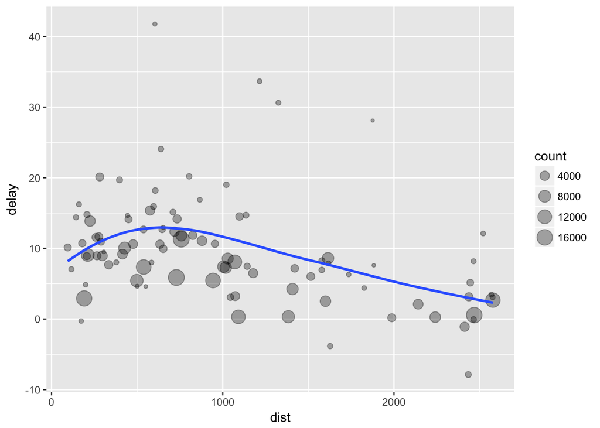

```r
ggplot(data = delay, mapping = aes(x = dist, y = delay)) +
  geom_point(aes(size = count), alpha = 1/3) +
  geom_smooth(se = FALSE)
```

This is an extraneous amount of code because I don’t really need/care about each intermediate dataframe. So focusing on the transformations instead of what’s being transformed, the whole shebang can be distilled using the pipe, `%>%` (can be thought of as imperative statements followed by the word “then”):

```r
delays <- flights %>%
  group_by(dest) %>%
  summarise(
    count = n(),
    dist = mean(distance, na.rm = TRUE),
    delay = mean(arr_delay, na.rm = TRUE)
  ) %>%
  filter(count > 20, dest != "HNL")

delays
```

```
## # A tibble: 96 × 4
##     dest count      dist     delay
##    <chr> <int>     <dbl>     <dbl>
## 1    ABQ   254 1826.0000  4.381890
## 2    ACK   265  199.0000  4.852273
## 3    ALB   439  143.0000 14.397129
## 4    ATL 17215  757.1082 11.300113
## 5    AUS  2439 1514.2530  6.019909
## 6    AVL   275  583.5818  8.003831
## 7    BDL   443  116.0000  7.048544
## 8    BGR   375  378.0000  8.027933
## 9    BHM   297  865.9966 16.877323
## 10   BNA  6333  758.2135 11.812459
## # ... with 86 more rows
```

### 5.6.2 Missing Values

What happens if you don’t set the `na.rm` parameter in some functions?

```r
flights %>%
  group_by(year, month, day) %>%
  summarize(mean = mean(dep_delay))
```

```
## Source: local data frame [365 x 4]
## Groups: year, month [?]
##
##     year month   day  mean
##    <int> <int> <int> <dbl>
## 1   2013     1     1    NA
## 2   2013     1     2    NA
## 3   2013     1     3    NA
## 4   2013     1     4    NA
## 5   2013     1     5    NA
## 6   2013     1     6    NA
## 7   2013     1     7    NA
## 8   2013     1     8    NA
## 9   2013     1     9    NA
## 10  2013     1    10    NA
## # ... with 355 more rows
```

What’s going on here? Look at the `dep_delay` variable first:

```r
jan_1 <- subset(flights, month == 1 & day == 1)
jan_1
```

```
## # A tibble: 842 × 19
##     year month   day dep_time sched_dep_time dep_delay arr_time
##    <int> <int> <int>    <int>          <int>     <dbl>    <int>
## 1   2013     1     1      517            515         2      830
## 2   2013     1     1      533            529         4      850
## 3   2013     1     1      542            540         2      923
## 4   2013     1     1      544            545        -1     1004
## 5   2013     1     1      554            600        -6      812
## 6   2013     1     1      554            558        -4      740
## 7   2013     1     1      555            600        -5      913
## 8   2013     1     1      557            600        -3      709
## 9   2013     1     1      557            600        -3      838
## 10  2013     1     1      558            600        -2      753
## # ... with 832 more rows, and 12 more variables: sched_arr_time <int>,
## #   arr_delay <dbl>, carrier <chr>, flight <int>, tailnum <chr>,
## #   origin <chr>, dest <chr>, air_time <dbl>, distance <dbl>, hour <dbl>,
## #   minute <dbl>, time_hour <dttm>
```

So there were 842 flights on January 1st 2013. What are the unique values in dep-delay?

```r
unique(jan_1$dep_delay)
```

```
##   [1]   2   4  -1  -6  -4  -5  -3  -2   0   1  -8   8  11   3  13  24  -7
##  [18]  -9   9  47  39 -10   5 101   7  71 -11 853   6  43  23  59  12  14
##  [35]  15  21  25  29 -15 -13  32 144  10  34  16  18 134  96  30  41  55
##  [52]  37  26  77  22  40  57  70  56  35  31 115  38  50  27 105 122  88
##  [69]  64 119  54  84  33  42  52  82  36 -14  91  62 103  74 290 260  61
##  [86]  63 131  19  46 129 155 157 216  73 121 109  51  72 255  49 285 -12
## [103] 141 192  83 116 379  NA
```

I see at least one of these flights has an NA in its `dep_delay`. Now check another day:

```r
jan_2 <- subset(flights, month == 2 & day == 1)
jan_2
```

```
## # A tibble: 926 × 19
##     year month   day dep_time sched_dep_time dep_delay arr_time
##    <int> <int> <int>    <int>          <int>     <dbl>    <int>
## 1   2013     2     1      456            500        -4      652
## 2   2013     2     1      520            525        -5      816
## 3   2013     2     1      527            530        -3      837
## 4   2013     2     1      532            540        -8     1007
## 5   2013     2     1      540            540         0      859
## 6   2013     2     1      552            600        -8      714
## 7   2013     2     1      552            600        -8      919
## 8   2013     2     1      552            600        -8      655
## 9   2013     2     1      553            600        -7      833
## 10  2013     2     1      553            600        -7      821
## # ... with 916 more rows, and 12 more variables: sched_arr_time <int>,
## #   arr_delay <dbl>, carrier <chr>, flight <int>, tailnum <chr>,
## #   origin <chr>, dest <chr>, air_time <dbl>, distance <dbl>, hour <dbl>,
## #   minute <dbl>, time_hour <dttm>
```

```r
unique(jan_2$dep_delay)
```

```
##   [1]  -4  -5  -3  -8   0  -7  -6  -2  -1   1   2 -11  12   5  -9  17  11
##  [18] -12 -10  30   7  10   4   6  13  37  18  26 -15  44  15  65   9  53
##  [35] 105 -14  27  14  21  81  28   3 124  82  34  54 118  35   8  46  24
##  [52]  49  99  22  67 104  84 106 119 126  56  29 191 -13  31  39  68  16
##  [69] 217 170  78  42  36 122 193  25 144  51  57  19  70  33  97  60  20
##  [86]  59  88 163  45  85  83  48  41  32  47  43  50  63 179  94 174  38
## [103] 161 150  64  96 123  66  89 288 195  93 121 224  72  92  61 148  73
## [120] 134 143  NA
```

Yes there is!

Now remember the rule with aggregation functions is that if there is and NA anywhere in the space it will resolve to NA. So I expect that if I group by and then apply an aggregation via `summarize()` that I will have two or more NA’s as a result. That’s what happened! Now, adding the `na.rm` parameter I get what I want:

```r
flights %>%
  group_by(year, month, day) %>%
  summarize(mean = mean(dep_delay, na.rm = TRUE))
```

```
## Source: local data frame [365 x 4]
## Groups: year, month [?]
##
##     year month   day      mean
##    <int> <int> <int>     <dbl>
## 1   2013     1     1 11.548926
## 2   2013     1     2 13.858824
## 3   2013     1     3 10.987832
## 4   2013     1     4  8.951595
## 5   2013     1     5  5.732218
## 6   2013     1     6  7.148014
## 7   2013     1     7  5.417204
## 8   2013     1     8  2.553073
## 9   2013     1     9  2.276477
## 10  2013     1    10  2.844995
## # ... with 355 more rows
```

It turns out the NA in this dataset represent canceled flights. Removing the cancelled flights, first create dataframe:

```r
not_cancelled <- flights %>%
  filter(!is.na(dep_delay), !is.na(arr_delay))
not_cancelled
```

```
## # A tibble: 327,346 × 19
##     year month   day dep_time sched_dep_time dep_delay arr_time
##    <int> <int> <int>    <int>          <int>     <dbl>    <int>
## 1   2013     1     1      517            515         2      830
## 2   2013     1     1      533            529         4      850
## 3   2013     1     1      542            540         2      923
## 4   2013     1     1      544            545        -1     1004
## 5   2013     1     1      554            600        -6      812
## 6   2013     1     1      554            558        -4      740
## 7   2013     1     1      555            600        -5      913
## 8   2013     1     1      557            600        -3      709
## 9   2013     1     1      557            600        -3      838
## 10  2013     1     1      558            600        -2      753
## # ... with 327,336 more rows, and 12 more variables: sched_arr_time <int>,
## #   arr_delay <dbl>, carrier <chr>, flight <int>, tailnum <chr>,
## #   origin <chr>, dest <chr>, air_time <dbl>, distance <dbl>, hour <dbl>,
## #   minute <dbl>, time_hour <dttm>
```

Now group by and summarize/aggrregate using my new dataframe:

```r
not_cancelled %>%
  group_by(year, month, day) %>%
  summarize(mean = mean(dep_delay))
```

```
## Source: local data frame [365 x 4]
## Groups: year, month [?]
##
##     year month   day      mean
##    <int> <int> <int>     <dbl>
## 1   2013     1     1 11.435620
## 2   2013     1     2 13.677802
## 3   2013     1     3 10.907778
## 4   2013     1     4  8.965859
## 5   2013     1     5  5.732218
## 6   2013     1     6  7.145959
## 7   2013     1     7  5.417204
## 8   2013     1     8  2.558296
## 9   2013     1     9  2.301232
## 10  2013     1    10  2.844995
## # ... with 355 more rows
```

### 5.6.3 Counts

When doing aggregation, good idea to include a count of missing values to make sure not drawing conclusions based on small amounts of data. Example, planes with highest average delays:

```r
delays <- not_cancelled %>%
  group_by(tailnum) %>%
  summarize(
    delay = mean(arr_delay))
delays
```

```
## # A tibble: 4,037 × 2
##    tailnum      delay
##      <chr>      <dbl>
## 1   D942DN 31.5000000
## 2   N0EGMQ  9.9829545
## 3   N10156 12.7172414
## 4   N102UW  2.9375000
## 5   N103US -6.9347826
## 6   N104UW  1.8043478
## 7   N10575 20.6914498
## 8   N105UW -0.2666667
## 9   N107US -5.7317073
## 10  N108UW -1.2500000
## # ... with 4,027 more rows
```

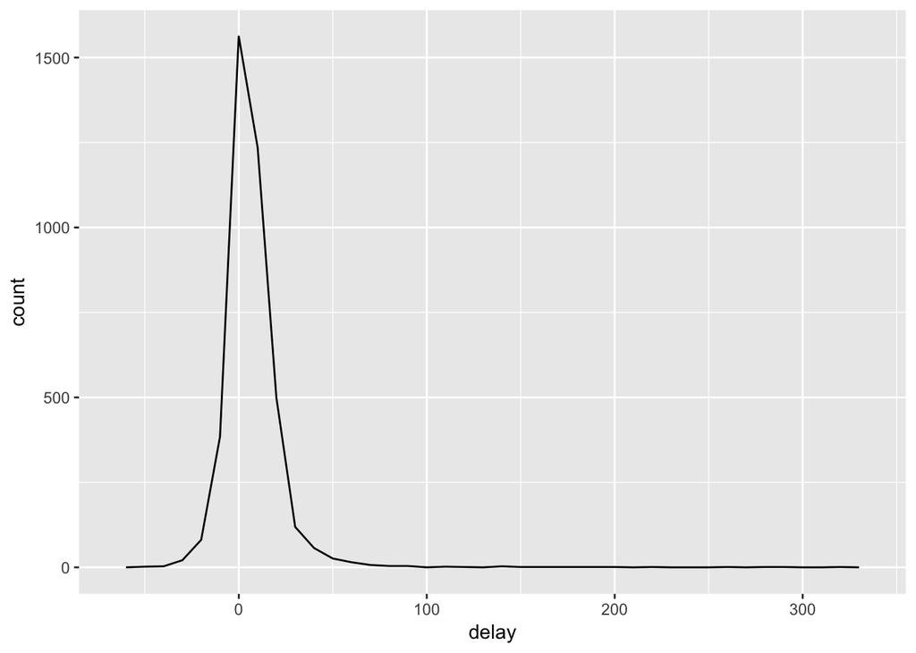

```r
ggplot(data = delays, mapping = aes(x = delay)) +
  geom_freqpoly(binwidth = 10)
```

Here, the mean arrival delays are grouped in bins of width 10 - so the vast majority of them were either a little early or less than about 25 minutes late arriving. But, some planes have an averave of over 300 minutes delay! But the story is a little more nuanced - draw a scatter plot to get more insights:

```r
delays <- not_cancelled %>%
  group_by(tailnum) %>%
  summarize(
    delay = mean(arr_delay, na.rm = TRUE),
    n = n()
  )
delays
```

```
## # A tibble: 4,037 × 3
##    tailnum      delay     n
##      <chr>      <dbl> <int>
## 1   D942DN 31.5000000     4
## 2   N0EGMQ  9.9829545   352
## 3   N10156 12.7172414   145
## 4   N102UW  2.9375000    48
## 5   N103US -6.9347826    46
## 6   N104UW  1.8043478    46
## 7   N10575 20.6914498   269
## 8   N105UW -0.2666667    45
## 9   N107US -5.7317073    41
## 10  N108UW -1.2500000    60
## # ... with 4,027 more rows
```

Now, plot:

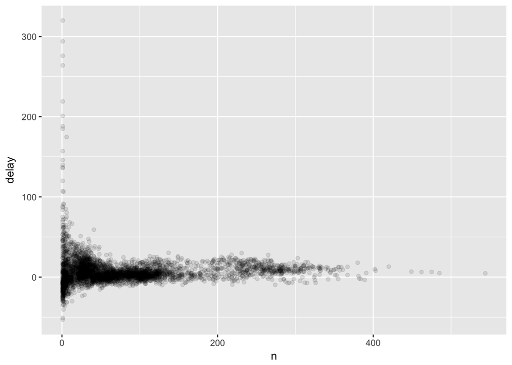

```r
ggplot(data = delays, mapping = aes(x = n, y = delay)) +
  geom_point(alpha = 1/10)
```

Note the variation decreases as the sample size increases - a common characteristic of plotting a mean (or other summary) vs. group size. Can filter out the groups with the smallest number of observations to see more of the pattern and less of the etreme varition (note, following code implements `ggplot` into the `dplyr` flow):

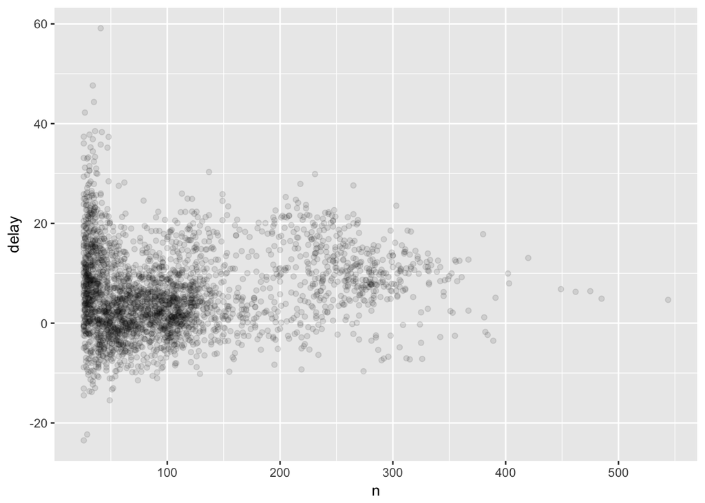

```r
delays %>%
  filter(n > 25) %>%
  ggplot(mapping = aes(x=n, y = delay)) +
    geom_point(alpha = 1/10)
```

Same pattern with average performance of batters in baseball related to number of times at bat. First, check out the dataframe:

```r
batting <- as_tibble(Lahman::Batting)
batting
```

```
## # A tibble: 101,332 × 22
##     playerID yearID stint teamID   lgID     G    AB     R     H   X2B
##        <chr>  <int> <int> <fctr> <fctr> <int> <int> <int> <int> <int>
## 1  abercda01   1871     1    TRO     NA     1     4     0     0     0
## 2   addybo01   1871     1    RC1     NA    25   118    30    32     6
## 3  allisar01   1871     1    CL1     NA    29   137    28    40     4
## 4  allisdo01   1871     1    WS3     NA    27   133    28    44    10
## 5  ansonca01   1871     1    RC1     NA    25   120    29    39    11
## 6  armstbo01   1871     1    FW1     NA    12    49     9    11     2
## 7  barkeal01   1871     1    RC1     NA     1     4     0     1     0
## 8  barnero01   1871     1    BS1     NA    31   157    66    63    10
## 9  barrebi01   1871     1    FW1     NA     1     5     1     1     1
## 10 barrofr01   1871     1    BS1     NA    18    86    13    13     2
## # ... with 101,322 more rows, and 12 more variables: X3B <int>, HR <int>,
## #   RBI <int>, SB <int>, CS <int>, BB <int>, SO <int>, IBB <int>,
## #   HBP <int>, SH <int>, SF <int>, GIDP <int>
```

Now group and summarize/aggregate:

```r
batters <- batting %>%
  group_by(playerID) %>%
  summarize(
    ba = sum(H, na.rm = TRUE) / sum(AB, na.rm = TRUE),
    ab = sum(AB, na.rm = TRUE)
  )
batters
```

```
## # A tibble: 18,659 × 3
##     playerID        ba    ab
##        <chr>     <dbl> <int>
## 1  aardsda01 0.0000000     4
## 2  aaronha01 0.3049984 12364
## 3  aaronto01 0.2288136   944
## 4   aasedo01 0.0000000     5
## 5   abadan01 0.0952381    21
## 6   abadfe01 0.1250000     8
## 7  abadijo01 0.2244898    49
## 8  abbated01 0.2536137  3044
## 9  abbeybe01 0.1688889   225
## 10 abbeych01 0.2809823  1751
## # ... with 18,649 more rows
```

Now plot:

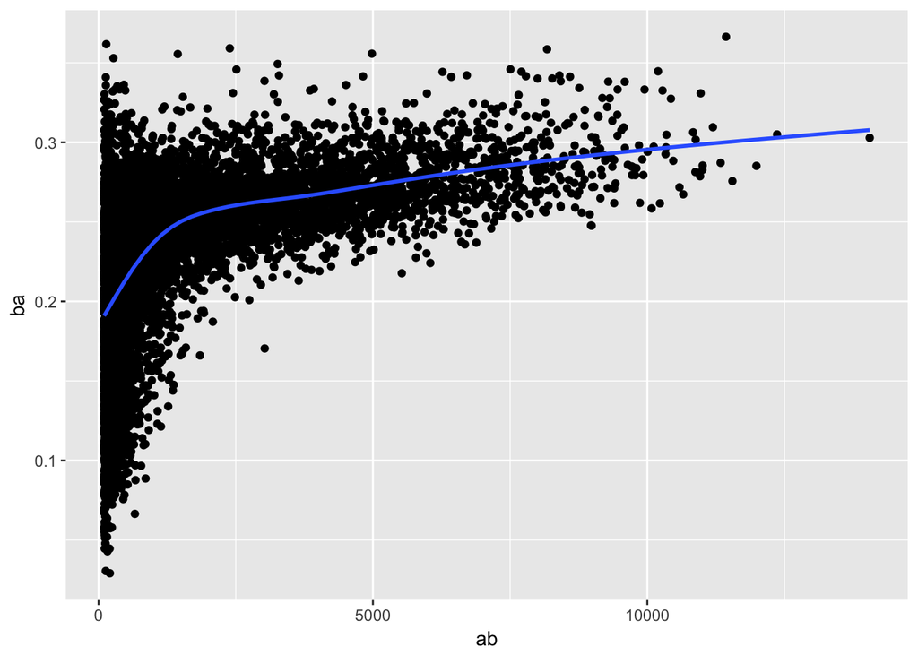

```r
batters %>%
  filter(ab > 100) %>%
  ggplot(mapping = aes(x = ab, y = ba)) +
  geom_point() +
  geom_smooth(se = FALSE)
```

Like the other plot, the variation in my chosen aggregate decreases as we get more data points. Also, there’s a positive correlation between skill (ba) and opportunities to hit the ball (ab). Obvious explanation is that teams choose who bats, and the ones with best batting average will be chosen to bat more.

Important implications for ranking - if naively sorting on `desc(ba)`, people with best batting averages are clearly lucky, not skilled:

```r
batters %>%
  arrange(desc(ba))
```

```
## # A tibble: 18,659 × 3
##     playerID    ba    ab
##        <chr> <dbl> <int>
## 1  abramge01     1     1
## 2  banisje01     1     1
## 3  bartocl01     1     1
## 4   bassdo01     1     1
## 5  birasst01     1     2
## 6  bruneju01     1     1
## 7  burnscb01     1     1
## 8  cammaer01     1     1
## 9   campsh01     1     1
## 10 crockcl01     1     1
## # ... with 18,649 more rows
```

See, people with only 1 at-bat got lucky here!

### 5.6.4 Useful Summary Functions

Measures of location:

- `mean(x)`
- `median(x)`

Practice combining aggregation with logical subsetting:

```r
not_cancelled %>%
  group_by(year, month, day) %>%
  summarize(
    avg_delay1 = mean(arr_delay),
    avg_delay2 = mean(arr_delay[arr_delay > 0])
  )
```

```
## Source: local data frame [365 x 5]
## Groups: year, month [?]
##
##     year month   day avg_delay1 avg_delay2
##    <int> <int> <int>      <dbl>      <dbl>
## 1   2013     1     1 12.6510229   32.48156
## 2   2013     1     2 12.6928879   32.02991
## 3   2013     1     3  5.7333333   27.66087
## 4   2013     1     4 -1.9328194   28.30976
## 5   2013     1     5 -1.5258020   22.55882
## 6   2013     1     6  4.2364294   24.37270
## 7   2013     1     7 -4.9473118   27.76132
## 8   2013     1     8 -3.2275785   20.78909
## 9   2013     1     9 -0.2642777   25.63415
## 10  2013     1    10 -5.8988159   27.34545
## # ... with 355 more rows
```

Measures of spread:

- `sd(x)` (standard deviation)
- `IRQ(x)` (interquartile range)
- `mad(x)` (mean absolute deviation)

```r
not_cancelled %>%
  group_by(dest) %>%
  summarize(distance_sd = sd(distance)) %>%
  arrange(desc(distance_sd))
```

```
## # A tibble: 104 × 2
##     dest distance_sd
##    <chr>       <dbl>
## 1    EGE   10.542765
## 2    SAN   10.350094
## 3    SFO   10.216017
## 4    HNL   10.004197
## 5    SEA    9.977993
## 6    LAS    9.907786
## 7    PDX    9.873299
## 8    PHX    9.862546
## 9    LAX    9.657195
## 10   IND    9.458066
## # ... with 94 more rows
```

Measures of rank:

- `min(x)`
- `quantile(x, 0.25)` (will find a value of `x` that is greater than 25% of the values and less than the remaining 75%)
- `max(x)`

```r
not_cancelled %>%
  group_by(year, month, day) %>%
  summarize(
    first = min(dep_time),
    last = max(dep_time)
  )
```

```
## Source: local data frame [365 x 5]
## Groups: year, month [?]
##
##     year month   day first  last
##    <int> <int> <int> <int> <int>
## 1   2013     1     1   517  2356
## 2   2013     1     2    42  2354
## 3   2013     1     3    32  2349
## 4   2013     1     4    25  2358
## 5   2013     1     5    14  2357
## 6   2013     1     6    16  2355
## 7   2013     1     7    49  2359
## 8   2013     1     8   454  2351
## 9   2013     1     9     2  2252
## 10  2013     1    10     3  2320
## # ... with 355 more rows
```

Measures of position:

- `first(x)`
- `nth(x, 2)`
- `last(x)`

They work like `x[1]`, `x[2]`, and `x[length(x)]` except you can set a default values if that position does not exist.

```r
not_cancelled %>%
  group_by(year, month, day) %>%
  summarise(
    first_dep = first(dep_time),
    last_dep = last(dep_time)
  )
```

```
## Source: local data frame [365 x 5]
## Groups: year, month [?]
##
##     year month   day first_dep last_dep
##    <int> <int> <int>     <int>    <int>
## 1   2013     1     1       517     2356
## 2   2013     1     2        42     2354
## 3   2013     1     3        32     2349
## 4   2013     1     4        25     2358
## 5   2013     1     5        14     2357
## 6   2013     1     6        16     2355
## 7   2013     1     7        49     2359
## 8   2013     1     8       454     2351
## 9   2013     1     9         2     2252
## 10  2013     1    10         3     2320
## # ... with 355 more rows
```

These functions are complimentary to filtering on ranks, but with filtering you get each observation in a separate row:

```r
not_cancelled %>%
  group_by(year, month, day) %>%
  mutate(r = min_rank(desc(dep_time))) %>%
  filter(r %in% range(r))
```

```
## Source: local data frame [770 x 20]
## Groups: year, month, day [365]
##
##     year month   day dep_time sched_dep_time dep_delay arr_time
##    <int> <int> <int>    <int>          <int>     <dbl>    <int>
## 1   2013     1     1      517            515         2      830
## 2   2013     1     1     2356           2359        -3      425
## 3   2013     1     2       42           2359        43      518
## 4   2013     1     2     2354           2359        -5      413
## 5   2013     1     3       32           2359        33      504
## 6   2013     1     3     2349           2359       -10      434
## 7   2013     1     4       25           2359        26      505
## 8   2013     1     4     2358           2359        -1      429
## 9   2013     1     4     2358           2359        -1      436
## 10  2013     1     5       14           2359        15      503
## # ... with 760 more rows, and 13 more variables: sched_arr_time <int>,
## #   arr_delay <dbl>, carrier <chr>, flight <int>, tailnum <chr>,
## #   origin <chr>, dest <chr>, air_time <dbl>, distance <dbl>, hour <dbl>,
## #   minute <dbl>, time_hour <dttm>, r <int>
```

Count:

- `n()`
- `sum(!is.na(x))`
- `n_distinct(x)`

Destinations with most carriers:

```r
not_cancelled %>%
  group_by(dest) %>%
  summarise(carriers = n_distinct(carrier)) %>%
  arrange(desc(carriers))
```

```
## # A tibble: 104 × 2
##     dest carriers
##    <chr>    <int>
## 1    ATL        7
## 2    BOS        7
## 3    CLT        7
## 4    ORD        7
## 5    TPA        7
## 6    AUS        6
## 7    DCA        6
## 8    DTW        6
## 9    IAD        6
## 10   MSP        6
## # ... with 94 more rows
```

Just count number of flights to each destination:

```r
not_cancelled %>%
  count(dest)
```

```
## # A tibble: 104 × 2
##     dest     n
##    <chr> <int>
## 1    ABQ   254
## 2    ACK   264
## 3    ALB   418
## 4    ANC     8
## 5    ATL 16837
## 6    AUS  2411
## 7    AVL   261
## 8    BDL   412
## 9    BGR   358
## 10   BHM   269
## # ... with 94 more rows
```

Add a weight - so count total numbers of miles a plane flew:

```r
not_cancelled %>%
  count(tailnum, wt = distance)
```

```
## # A tibble: 4,037 × 2
##    tailnum      n
##      <chr>  <dbl>
## 1   D942DN   3418
## 2   N0EGMQ 239143
## 3   N10156 109664
## 4   N102UW  25722
## 5   N103US  24619
## 6   N104UW  24616
## 7   N10575 139903
## 8   N105UW  23618
## 9   N107US  21677
## 10  N108UW  32070
## # ... with 4,027 more rows
```

Number of flicths leaving before 5am:

```r
not_cancelled %>%
  group_by(year, month, day) %>%
  summarise(n_early = sum(dep_time < 500))
```

```
## Source: local data frame [365 x 4]
## Groups: year, month [?]
##
##     year month   day n_early
##    <int> <int> <int>   <int>
## 1   2013     1     1       0
## 2   2013     1     2       3
## 3   2013     1     3       4
## 4   2013     1     4       3
## 5   2013     1     5       3
## 6   2013     1     6       2
## 7   2013     1     7       2
## 8   2013     1     8       1
## 9   2013     1     9       3
## 10  2013     1    10       3
## # ... with 355 more rows
```

Proportion of flights delayed more than one hour:

```r
not_cancelled %>%
  group_by(year, month, day) %>%
  summarise(hour_perc = mean(arr_delay > 60))
```

```
## Source: local data frame [365 x 4]
## Groups: year, month [?]
##
##     year month   day  hour_perc
##    <int> <int> <int>      <dbl>
## 1   2013     1     1 0.07220217
## 2   2013     1     2 0.08512931
## 3   2013     1     3 0.05666667
## 4   2013     1     4 0.03964758
## 5   2013     1     5 0.03486750
## 6   2013     1     6 0.04704463
## 7   2013     1     7 0.03333333
## 8   2013     1     8 0.02130045
## 9   2013     1     9 0.02015677
## 10  2013     1    10 0.01829925
## # ... with 355 more rows
```

### Grouping by Multiple Variables:

Flights per day:

```r
daily <- group_by(flights, year, month, day)
per_day <- summarize(daily, flights = n())
per_day
```

```
## Source: local data frame [365 x 4]
## Groups: year, month [?]
##
##     year month   day flights
##    <int> <int> <int>   <int>
## 1   2013     1     1     842
## 2   2013     1     2     943
## 3   2013     1     3     914
## 4   2013     1     4     915
## 5   2013     1     5     720
## 6   2013     1     6     832
## 7   2013     1     7     933
## 8   2013     1     8     899
## 9   2013     1     9     902
## 10  2013     1    10     932
## # ... with 355 more rows
```

```r
per_month <- summarize(per_day, flights = sum(flights))
per_month
```

```
## Source: local data frame [12 x 3]
## Groups: year [?]
##
##     year month flights
##    <int> <int>   <int>
## 1   2013     1   27004
## 2   2013     2   24951
## 3   2013     3   28834
## 4   2013     4   28330
## 5   2013     5   28796
## 6   2013     6   28243
## 7   2013     7   29425
## 8   2013     8   29327
## 9   2013     9   27574
## 10  2013    10   28889
## 11  2013    11   27268
## 12  2013    12   28135
```

```r
per_year <- summarize(per_month, flights = sum(flights))
per_year
```

```
## # A tibble: 1 × 2
##    year flights
##   <int>   <int>
## 1  2013  336776
```

### Ungrouping

Return to operations on ungrouped data:

```r
daily %>%
  ungroup() %>%
  summarize(flights = n())
```

```
## # A tibble: 1 × 1
##   flights
##     <int>
## 1  336776
```

### 5.6.7 Exercises

TODO

### Grouped Mutates (and filters)

`mutate()` and `filter()` can also be used when grouping. Find the worst members of each group:

```r
flights_sml %>%
  group_by(year, month, day) %>%
  filter(rank(desc(arr_delay)) < 10)
```

```
## Source: local data frame [3,306 x 7]
## Groups: year, month, day [365]
##
##     year month   day dep_delay arr_delay distance air_time
##    <int> <int> <int>     <dbl>     <dbl>    <dbl>    <dbl>
## 1   2013     1     1       853       851      184       41
## 2   2013     1     1       290       338     1134      213
## 3   2013     1     1       260       263      266       46
## 4   2013     1     1       157       174      213       60
## 5   2013     1     1       216       222      708      121
## 6   2013     1     1       255       250      589      115
## 7   2013     1     1       285       246     1085      146
## 8   2013     1     1       192       191      199       44
## 9   2013     1     1       379       456     1092      222
## 10  2013     1     2       224       207      550       94
## # ... with 3,296 more rows
```

All groups bigger than a threshold:

```r
popular_dests <- flights %>%
  group_by(dest) %>%
  filter(n() > 365)
popular_dests
```

```
## Source: local data frame [332,577 x 19]
## Groups: dest [77]
##
##     year month   day dep_time sched_dep_time dep_delay arr_time
##    <int> <int> <int>    <int>          <int>     <dbl>    <int>
## 1   2013     1     1      517            515         2      830
## 2   2013     1     1      533            529         4      850
## 3   2013     1     1      542            540         2      923
## 4   2013     1     1      544            545        -1     1004
## 5   2013     1     1      554            600        -6      812
## 6   2013     1     1      554            558        -4      740
## 7   2013     1     1      555            600        -5      913
## 8   2013     1     1      557            600        -3      709
## 9   2013     1     1      557            600        -3      838
## 10  2013     1     1      558            600        -2      753
## # ... with 332,567 more rows, and 12 more variables: sched_arr_time <int>,
## #   arr_delay <dbl>, carrier <chr>, flight <int>, tailnum <chr>,
## #   origin <chr>, dest <chr>, air_time <dbl>, distance <dbl>, hour <dbl>,
## #   minute <dbl>, time_hour <dttm>
```

Standardize to compute per group metrics:

```r
popular_dests %>%
  filter(arr_delay > 0) %>%
  mutate(prop_delay = arr_delay / sum(arr_delay)) %>%
  select(year:day, dest, arr_delay, prop_delay)
```

```
## Source: local data frame [131,106 x 6]
## Groups: dest [77]
##
##     year month   day  dest arr_delay   prop_delay
##    <int> <int> <int> <chr>     <dbl>        <dbl>
## 1   2013     1     1   IAH        11 1.106740e-04
## 2   2013     1     1   IAH        20 2.012255e-04
## 3   2013     1     1   MIA        33 2.350026e-04
## 4   2013     1     1   ORD        12 4.239594e-05
## 5   2013     1     1   FLL        19 9.377853e-05
## 6   2013     1     1   ORD         8 2.826396e-05
## 7   2013     1     1   LAX         7 3.444441e-05
## 8   2013     1     1   DFW        31 2.817951e-04
## 9   2013     1     1   ATL        12 3.996017e-05
## 10  2013     1     1   DTW        16 1.157257e-04
## # ... with 131,096 more rows
```

Grouped filter is a grouped mutate followed by an ungrouped filter. Usually avoid except for quick and dirty manipulations.

### 5.7.1 Exercises

TODO